# Himalayan Climbing Expeditions

Ekaterina Cheliadinova

01/11/2020

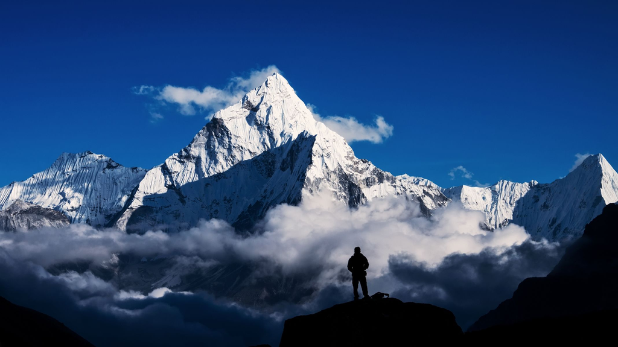

La base de données ‘Himalayan Climbing Expeditions’ permet d’observer toutes les expéditions dans l’Himalaya au Népal. La base de données s’appuie sur les archives de l’expédition d’Elizabeth Hawley, journaliste de longue date basée à Katmandou, et est complétée par des informations recueillies à partir de livres, de revues alpines et de correspondance avec des alpinistes himalayens.

Les données couvrent toutes les expéditions de 1905 au printemps 2019 jusqu’à plus de 465 sommets importants au Népal. Des expéditions des deux côtés des sommets frontaliers tels que l’Everest, Cho Oyu, Makalu et Kangchenjunga ainsi que vers certains sommets frontaliers plus petits sont également incluses. Les données sur les expéditions vers les sommets de trekking sont incluses pour les premières tentatives, les premières ascensions et les accidents majeurs.

## Questions:

##### **1. Quel est l’âge moyen des membres des expéditions?**

```r
mean(members$age, na.rm = T)
```

```
## [1] 37.3343
```

##### **2. Сombien de femmes et d’hommes ont participé aux expéditions chaque année?**

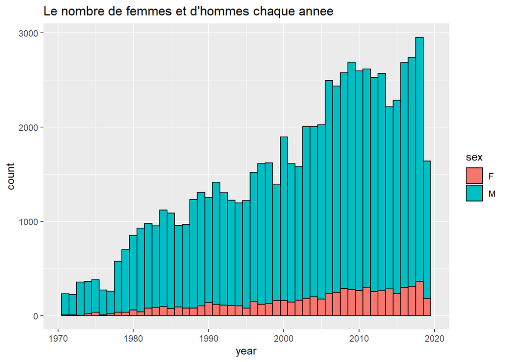

```r
y = 1970

members %>%
  filter(year>y) %>%
  group_by(year, sex) %>%
  summarise(n = n()) %>%
  pivot_wider(names_from = sex,values_from = n) %>%
  mutate(perc = F/(F+M)) ->df


members %>%
  filter(year>y) %>%
  group_by(year, sex) %>%
  summarise(n = n()) %>%
  drop_na(sex) %>%
  ggplot( aes(year, n , fill = sex)) +
  geom_bar(stat = "identity", width = 1, color = 'black',position = position_stack(reverse = TRUE)) +
  labs(y = "count",
       x = "year",
       title = "Le nombre de femmes et d'hommes chaque année")
```

##### **3. Est-ce que chaque année en moyenne le nombre de femmes participant aux expéditions a augmenté?**

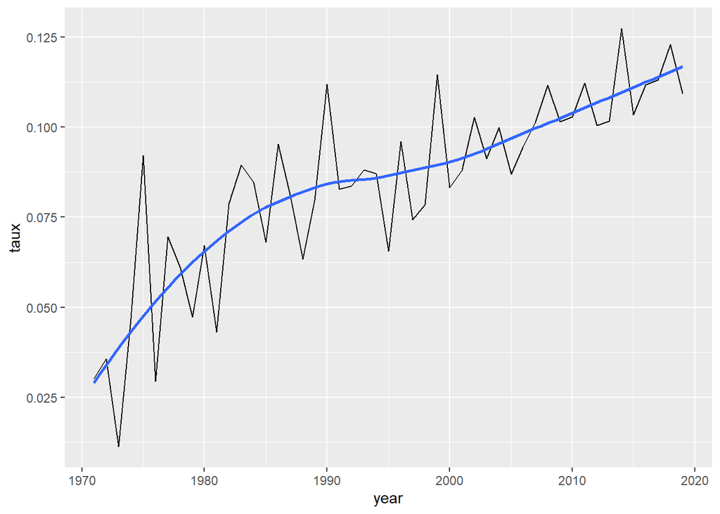

```r
members %>%
  filter(year>1970) %>%
  group_by(year, sex) %>%
  summarise(n = n()) %>%
  drop_na(sex) %>%
  pivot_wider(names_from =sex, values_from = n) %>%
  mutate(F = replace_na(F,0)) %>%
  mutate(taux = F/(M+F)) %>%
  ggplot( aes(year, taux)) +
  geom_line()+
  geom_smooth(se = FALSE)
```

##### **4. Quelles sont les principales raisons pour lesquelles les expéditions ont échoué avant et après 1980?**

```r
expeditions %>%
  filter(year <1980 & termination_reason != 'Success (main peak)' & termination_reason != 'Success (subpeak)' &  termination_reason != 'Success (claimed)') %>%
  drop_na(termination_reason) %>%
  group_by(termination_reason) %>%
  summarise(n = n()) %>%
  arrange(-n) %>%
  top_n(5) %>%
  kbl(col.names = c('termination reason','count')) %>%
  kable_styling(bootstrap_options = c("striped", "hover", "condensed"))
```

| termination reason | count |
| --- | --- |
| Did not attempt climb | 81 |
| Route technically too difficult, lack of experience, strength, or motivation | 79 |
| Bad weather (storms, high winds) | 78 |
| Accident (death or serious injury) | 48 |
| Bad conditions (deep snow, avalanching, falling ice, or rock) | 37 |

| termination reason | count |
| --- | --- |
| Bad weather (storms, high winds) | 1229 |
| Bad conditions (deep snow, avalanching, falling ice, or rock) | 1060 |
| Illness, AMS, exhaustion, or frostbite | 441 |
| Route technically too difficult, lack of experience, strength, or motivation | 359 |
| Other | 284 |

##### **5. Quelle est la distribution de la hauteur des pics?**

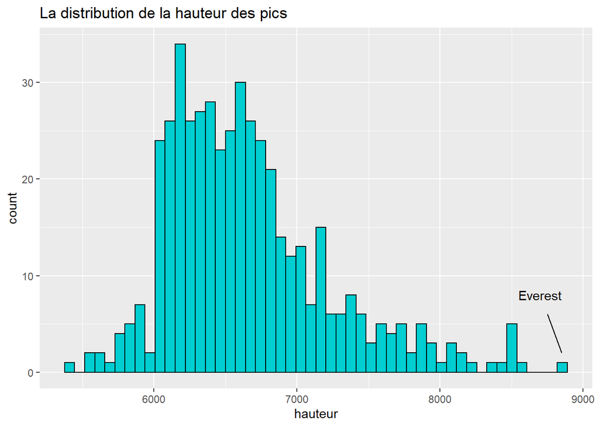

```r
peaks %>%
  ggplot(aes(height_metres))+
  geom_histogram(bins = 50,fill = 'darkturquoise',color = 'black')+
  labs(y = "count",
       x = "hauteur",
       title = "La distribution de la hauteur des pics")+

  annotate("text", x = 8700, y = 8, label = "Everest", color = 'black')+
  annotate("segment", x = 8750, xend = 8850, y = 6, yend = 2,
  colour = "black")
```

##### **6. Quels sont les pics les plus dangereux parmi les plus populaires?**

```r
expeditions %>%
  group_by(peak_name) %>%
  summarise(sum = sum(member_deaths)+sum(hired_staff_deaths), n = sum(members)+sum(hired_staff)) %>%
  mutate(taux = 100*sum/n) %>%
  arrange(-taux) %>%
  left_join(select(peaks,peak_name,height_metres)) %>%
  filter(n>1000) %>%
  slice(1:10) %>%
  mutate(taux = round(taux, 3)) %>%
  kbl(col.names = c('pick','nombre de morts','nombre total','taux de mortalite','hauteur')) %>%
  kable_styling(bootstrap_options = c("striped", "hover", "condensed")) %>%
  row_spec(row = 7,color = 'red')
```

| pick | nombre de morts | nombre total | taux de mortalite | hauteur |
| --- | --- | --- | --- | --- |
| Annapurna I | 72 | 2000 | 3.600 | 8091 |
| Kangchenjunga | 51 | 1797 | 2.838 | 8586 |
| Dhaulagiri I | 85 | 3022 | 2.813 | 8167 |
| Pumori | 42 | 1931 | 2.175 | 7138 |
| Makalu | 48 | 2891 | 1.660 | 8485 |
| Manaslu | 85 | 5136 | 1.655 | 8163 |
| Everest | 306 | 28022 | 1.092 | 8850 |
| Lhotse | 21 | 3107 | 0.676 | 8516 |
| Baruntse | 13 | 2365 | 0.550 | 7152 |
| Cho Oyu | 52 | 9777 | 0.532 | 8188 |

##### **7. Quelle saison est la plus appropriée pour une expédition c.-à-d. avec le taux de réussite le plus élevé?**

```r
expeditions$success <- with(expeditions,ifelse(termination_reason == 'Success (main peak)' | termination_reason == 'Success (subpeak)' |  termination_reason == 'Success (claimed)', TRUE,FALSE))

expeditions %>%
  group_by(season, success) %>%
  summarise(n_success = n()) %>%
  filter(season!='Unknown') %>%
  group_by(season) %>%
  mutate(Percentage = n_success/sum(n_success), total = sum(n_success)) %>%
  filter(success == TRUE) %>%
  arrange(-Percentage) %>%
  select(season,Percentage) %>%
  kbl(col.names = c('Saison','taux de réussite')) %>%
  kable_styling(bootstrap_options = c("striped", "hover", "condensed"))
```

| Saison | taux de reussite |
| --- | --- |
| Spring | 0.5694359 |
| Autumn | 0.5462085 |
| Winter | 0.4539683 |
| Summer | 0.3796296 |

##### **8. Est-ce qu’il y a une correlation entre la reussite et l’age?**

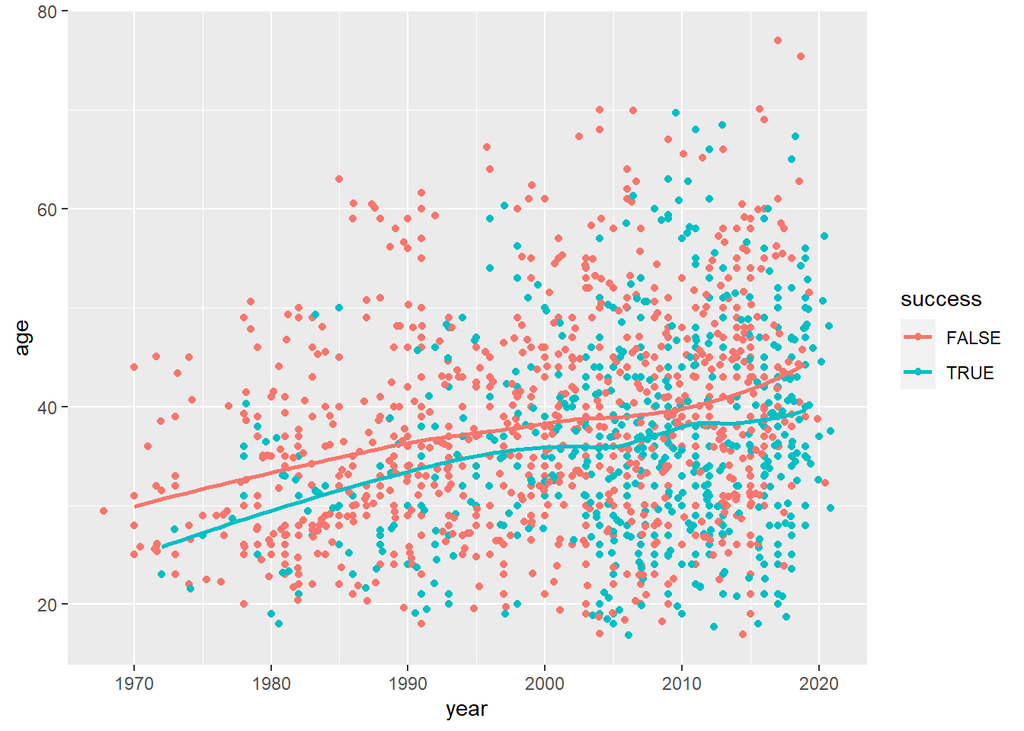

```r
members %>%
  filter(year>=1970) %>%
  sample_n(800) %>%
  drop_na(year,age,success) %>%
  ggplot(aes(x = year, y = age, color = success))+
  geom_point()+
  geom_jitter(width = 2.5, height = 2.5)+
  geom_smooth(se = FALSE)
```

```r
cor(members$age,with(members,ifelse(success == TRUE,1,0)),use = "complete.obs")
```

```
## [1] -0.09557941
```

##### **9. Y a-t-il un lien entre le succès de l’expédition et le nombre de membres?**

```r
expeditions %>%
  mutate(n_members = members + hired_staff ) %>%
  drop_na(n_members) -> corr_2

cor(corr_2$n_members, with(corr_2, ifelse(success == TRUE,1,0)))
```

```
## [1] 0.1499242
```

##### **10. Y at-il une corrélation entre le sexe et le succès?**

```r
succ <- with(members, ifelse(success == TRUE,1,0))
sex <- with(members, ifelse(sex == 'M',1,0))

cor.test(sex,succ, use = "complete.obs")
```

```
##
##  Pearson's product-moment correlation
##
## data:  sex and succ
## t = 9.8345, df = 76515, p-value < 2.2e-16
## alternative hypothesis: true correlation is not equal to 0
## 95 percent confidence interval:
##  0.02845235 0.04260546
## sample estimates:
##        cor
## 0.03553069
```

##### **11. Les expéditions en solo ont-elles un taux de réussite plus élevé?**

```r
suc <-with(members,ifelse(success==TRUE,1,0))
solo <-with(members, ifelse(solo==TRUE,1,0))

cor.test(solo,suc, use = "complete.obs")
```

```
##
##  Pearson's product-moment correlation
##
## data:  solo and suc
## t = 5.7748, df = 76517, p-value = 7.732e-09
## alternative hypothesis: true correlation is not equal to 0
## 95 percent confidence interval:
##  0.01378875 0.02795339
## sample estimates:
##        cor
## 0.02087212
```

##### **12. Quels pays ont connu le plus de succès depuis 1985?**

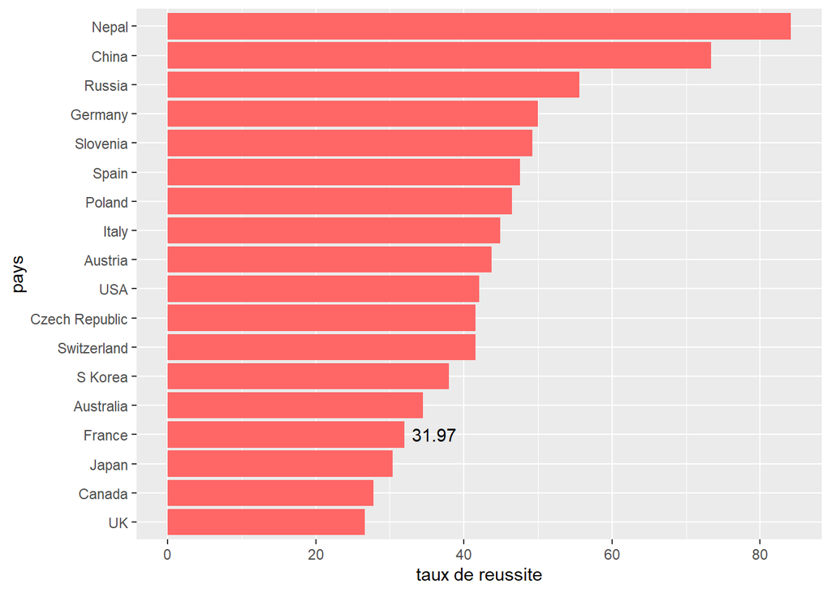

```r
expeditions$suc <- with(expeditions,ifelse(termination_reason == 'Success (main peak)' | termination_reason == 'Success (subpeak)' |  termination_reason == 'Success (claimed)', 1,0))

expeditions %>%
  filter(year>1985) %>%
  left_join(members,by = 'expedition_id') %>%
  group_by(expedition_id, citizenship,suc ) %>%
  summarise(n = n()) ->d

d[d$expedition_id %in% names(which(table(d$expedition_id) < 2)), ] %>%
  group_by(citizenship,suc) %>%
  summarise(n = n()) %>%
  group_by(citizenship) %>%
  mutate(Percentage = 100*n/sum(n), total = sum(n)) %>%
  filter(suc==1&total>=50) %>%
  drop_na() %>%
  arrange(-Percentage) %>%
  ggplot(aes(y = reorder(citizenship,Percentage),x = Percentage))+
  geom_col( fill='#FF6666')+
  labs(y = "pays",
       x = "taux de réussite")+
  annotate("text", x = 36, y = 4, label = 31.97, color = 'black')
```

##### **13. Quelle est la meilleure compagnie d’expédition?**

```r
expeditions %>%
  group_by(trekking_agency, suc) %>%
  summarise(n = n()) %>%
  pivot_wider(names_from =suc, values_from = n) %>%
  rename(fail = '0') %>%
  rename(success = '1') %>%
  mutate(fail = replace_na(fail,0),success = replace_na(success,0),total = success+fail, percent_of_success = success/total) %>%
  filter(total>=100) %>%
  arrange(-percent_of_success) %>%
  drop_na() %>%
  head(5) %>%
  kbl(col.names = c('trekking agency','success','fail','total','percent of success')) %>%
  kable_styling(bootstrap_options = c("striped", "hover", "condensed"))
```

| trekking agency | success | fail | total | percent of success |
| --- | --- | --- | --- | --- |
| Everest Parivar | 104 | 28 | 132 | 0.7878788 |
| Himalayan Guides | 262 | 112 | 374 | 0.7005348 |
| Mountain Experience | 70 | 32 | 102 | 0.6862745 |
| Arun Treks | 97 | 51 | 148 | 0.6554054 |
| Seven Summit Treks | 202 | 111 | 313 | 0.6453674 |